# The Need for Speed

## Overview

## Overview

- Higher level languages such as Python are optimized for humans
- This means that the programmer can leave many details to the runtime environment
  - specifying variable types, memory allocation/deallocation, etc.
- One result is that, compared to low-level languages, Python is typically faster to write, less error prone and easier to debug
- One downside is that Python is harder to optimize a that is, turn into fast machine code a than languages like C or Fortran
- Indeed, the standard implementation of Python (called CPython) cannot match the speed of compiled languages such as C or Fortran

## Overview

- Fortunately, this turns out to be a relatively small problem, since
  1. Of any given program, relatively few lines are time-critical
  2. For those lines of code that are time-critical, we can achieve C-like speeds with minor modifications
- This lecture will walk you through some of the most popular options for implementing this last step

## Where are the Bottlenecks?

## Dynamic Typing

- Let's start by trying to understand why high level languages like Python are slower than compiled code
- Consider this Python operation

```python
a, b = 10, 10
a + b
```

- Even for this simple operation, the Python interpreter has a fair bit of work to do
- For example, in the statement a + b, the interpreter has to know which operation to invoke

## Dynamic Typing

- If a and b are strings, then a + b requires string concatenation

```python
a, b = 'foo', 'bar'
a + b
```

- If a and b are lists, then `a + b` requires list concatenation

```python
a, b = ['foo'], ['bar']
a + b
```

- We say that the operator + is overloaded a its action depends on the type of the objects on which it acts
- As a result, Python must check the type of the objects and then call the correct operation
- This involves substantial overheads

## Static Types

- Compiled languages avoid these overheads with explicit, static types
- For example, consider the following C code, which sums the integers from 1 to 10

```c
#include <stdio.h>
int main(void) {
    int i;
    int sum = 0;
    for (i = 1; i <= 10; i++) {
        sum = sum + i;
    }
    printf("sum = %d\n", sum);
    return 0;
}
```

## Static Types

- The variables `i` and `sum` are explicitly declared to be integers
- Hence the meaning of addition here is completely unambiguous

## Data Access

- Another drag on speed for high level languages is data access
- To illustrate, let's consider the problem of summing some data a say, a collection of integers

## Summing with Compiled Code

- In C or Fortran, these integers would typically be stored in an array, which is a simple data structure for storing homogeneous data
- Such an array is stored in a single contiguous block of memory
  - In modern computers, memory addresses are allocated to each byte (one byte = 8 bits)
  - For example, a 64 bit integer is stored in 8 bytes of memory
  - An array of n such integers occupies 8n consecutive memory slots
- Moreover, the compiler is made aware of the data type by the programmer
  - In this case 64 bit integers
- Hence each successive data point can be accessed by shifting forward in memory space by a known and fixed amount
  - In this case 8 bytes

## Summing in Pure Python

- Python tries to replicate these ideas to some degree
- For example, in the standard Python implementation (CPython), list elements are placed in memory locations that are in a sense contiguous
- However, these list elements are more like pointers to data rather than actual data
- Hence there is still overhead involved in accessing the data values themselves
- This is a considerable drag on speed
- In fact it's generally true that memory traffic is a major culprit when it comes to slow execution
- Let's look at some ways around these problems

## Vectorization

## Vectorization

- Vectorization is about sending batches of related operations to native machine code
  - The machine code itself is typically compiled from carefully optimized C or Fortran
- This can greatly accelerate many a but not all a numerical computations

## Operations on Arrays

- Try executing the following in an IPython notebook cell

```python
import random
import numpy as np

%%timeit
n = 100000
sum = 0
for i in range(n):
    x = random.uniform(0, 1)
    sum += x**2

%%timeit
n = 100000
x = np.random.uniform(0, 1, n)
np.sum(x**2)
```

## Operations on Arrays

- You should find that the second code block a which achieves the same thing as the first a runs one to two orders of magnitude faster
- The reason is that in the second implementation we have broken the loop down into three basic operations
  - draw n uniforms
  - square them
  - sum them
- These are sent as batch operators to optimized machine code
- Apart from minor overheads associated with sending data back and forth, the result is C- or Fortran-like speed

## Operations on Arrays

- When we run batch operations on arrays like this, we say that the code is vectorized
- Although there are exceptions, vectorized code is typically fast and efficient
- It is also surprisingly flexible, in the sense that many operations can be vectorized

## Universal Functions

- Many functions provided by NumPy are so-called *universal functions* a also called *ufuncs*
- This means that they
  - map scalars into scalars, as expected
  - map arrays into arrays, acting elementwise
- For example, `np.cos` is a ufunc:

```python
import numpy as np
np.cos(1.0)

np.cos(np.linspace(0, 1, 3))
```

- By exploiting ufuncs, many operations can be vectorized

## Universal Functions

- For example, consider the problem of maximizing a function \(f\) of two variables \((x,y)\) over the square \([-a,a]\times[-a,a]\)
- For \(f\) and \(a\) let's choose \[ f(x,y)=\frac{\cos(x^2+y^2)}{1+x^2+y^2}\:\text{and}\:a=3 \]

## Universal Functions

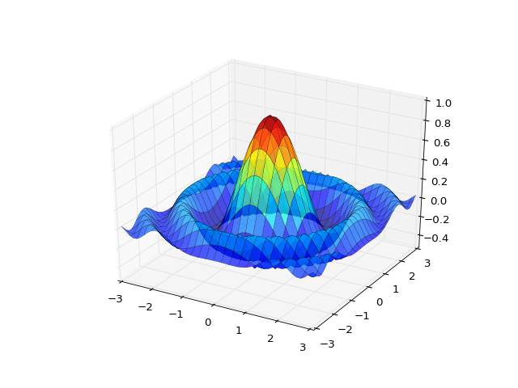

## Universal Functions

- To maximize it we're going to use a naive grid search:
  1. Evaluate \(f\) for all \((x,y)\) in a grid on the square
  2. Return the maximum of observed values
- Here's a non-vectorized version that uses Python loops

```python
import numpy as np
def f(x, y):
    return np.cos(x**2 + y**2) / (1 + x**2 + y**2)
grid = np.linspace(-3, 3, 1000)
m = -np.inf
for x in grid:
    for y in grid:
        z = f(x, y)
        if z > m:
            m = z
print(m)
```

## Universal Functions

- And here's a vectorized version

```python
import numpy as np
def f(x, y):
    return np.cos(x**2 + y**2) / (1 + x**2 + y**2)
grid = np.linspace(-3, 3, 1000)
x, y = np.meshgrid(grid, grid)
print(np.max(f(x, y)))
```

- In the vectorized version all the looping takes place in compiled code
- If you add `%%timeit` to the top of these code snippets and run them in a notebook cell, you'll see that the second version is much faster a about two orders of magnitude

## Pros and Cons of Vectorization

- At its best, vectorization yields fast, simple code
- However, it's not without disadvantages
- One issue is that it can be highly memory intensive
- For example, the vectorized maximization routine above is far more memory intensive than the non-vectorized version that preceded it
- Another issue is that not all algorithms can be vectorized
- In these kinds of settings, we need to go back to loops
- Fortunately, there are very nice ways to speed up Python loops

## Numba

## Numba

- One of the most exciting developments in recent years in terms of scientific Python is Numba
- Numba aims to automatically compile functions to native machine code instructions on the fly
- The process isn't flawless, since Numba needs to infer type information on all variables to generate pure machine instructions
- Such inference isn't possible in every setting
- But for simple routines Numba infers types very well
- Moreover, the ahot loopsa at the heart of our code that we need to speed up are often such simple routines

## Prerequisites

- If you followed our set up instructions and installed Anaconda, then you'll be ready to use Numba
- If you do have Anaconda installed, now might be a good time to run conda update numba from a system terminal

## An Example

- Let's consider some problems that are difficult to vectorize
- One is generating the trajectory of a difference equation given an initial condition
- Let's take the difference equation to be the quadratic map \[ x_{t+1}=4x_t(1-x_t) \]
- Here's the plot of a typical trajectory, starting from \(x_0=0.1\), with \(t\) on the x-axis

## An Example

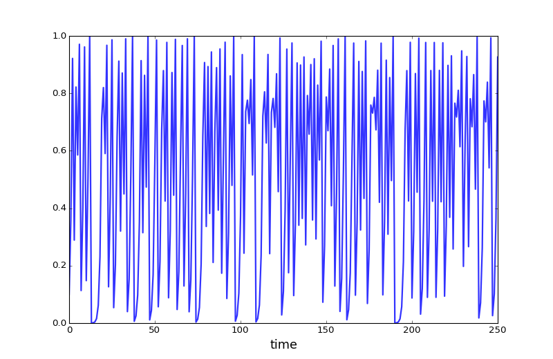

## An Example

- Before starting let's do some imports

```python
from numba import jit
import numpy as np
```

- Now here's a function to generate a trajectory of a given length from a given initial condition

```python
def qm(x0, n):
    x = np.empty(n+1)
    x[0] = x0
    for t in range(n):
        x[t+1] = 4 * x[t] * (1 - x[t])
    return x
```

## An Example

- To speed this up using Numba is trivial

```python
qm_numba = jit(qm)  # qm_numba is now a 'compiled' version of qm
```

- Alternatively, we can just put `@jit` before the function

```python
@jit
def qm_numba(x0, n):
    x = np.empty(n+1)
    x[0] = x0
    for t in range(n):
        x[t+1] = 4 * x[t] * (1 - x[t])
    return x
```

## An Example

- Here the function body is identical to `qm` a the name has been changed only to aid speed comparisons
- Timing the function calls `qm(0.1, 100000)` and `qm_numba(0.1, 100000)` gives us a speed-up factor in the order of 200 times
- Your mileage may vary depending on your hardware and version of Numba, but anything in this neighborhood is remarkable given how trivial the implementation is

## How and When it Works

- Numba attempts to generate fast machine code using the infrastructure provided by the LLVM Project
- It does this by inferring type information on the fly
- As you can imagine, this is easier for simple Python objects (simple scalar data types, such as floats, integers, etc.)
- Numba also plays well with NumPy arrays, which it treats as typed memory regions
- In an ideal setting, Numba can infer all necessary type information
- This allows it to generate native machine code, without having to call the Python runtime environment
- In such a setting, Numba will be on par with machine code from low level languages

## How and When it Works

- When Numba cannot infer all type information, some Python objects are given generic object status, and some code is generated using the Python runtime
- In this second setting, Numba typically provides only minor speed gains a or none at all
- Hence it's prudent when using Numba to focus on speeding up small, time-critical snippets of code
- This will give you much better performance than blanketing your Python programs with `@jit` statements

## Other Options

## Other Options

- There are in fact many other approaches to speeding up your Python code
- We mention only a few of the most popular methods

## Interfacing with Fortran

- If you are comfortable writing Fortran you will find it very easy to create extention modules from Fortran code using F2Py
- F2Py is a Fortran-to-Python interface generator that is particularly simple to use
- Robert Johansson provides a very nice introduction to F2Py, among other things
- Recently, an IPython cell magic for Fortran has been developed a you might want to give it a try

## Parallel and Cloud Computing

- This is a big topic that we won't address in detail yet
- However, you might find the following items a useful starting point
  - IPython for parallel computing
  - NumbaPro
  - The Starcluster interface to Amazon's EC2
  - Anaconda Accelerate

## Exercises

## Exercises 1

- Later we'll learn all about finite state Markov chains
- For now let's just concentrate on simulating a very simple example of such a chain
- Suppose that the volatility of returns on an asset can be in one of two regimes a high or low
- The transition probabilities across states are as follows
  - "low" -> "low" "0.9";
  - "low" -> "high" "0.1";
  - "high" -> "low" "0.2";
  - "high" -> "high" "0.8";
- Your task is to simulate a sequence of monthly volatility states according to this rule

## Exercises 1

- Set the length of the sequence to n = 100000 and start in the high state
- Implement a pure Python version, and a Numba version, and compare speeds
- To test your code, evaluate the fraction of time that the chain spends in the low state
- If your code is correct, it should be about 2/3

## Appendix a Other Options

- There are other important projects aimed at speeding up Python
- These include but are not limited to
  - Pythran : A Python to C++ compiler
  - Parakeet : A runtime compiler aimed at scientific computing in Python
  - PyPy : Runtime environment using just-in-time compiler
  - Nuitka : Another Python compiler
  - Pyston : Under development, sponsored by Dropbox